# Reading/Writing in Python

## Formats typically used for data storage (and ways to read them in)

Text files (.txt, .csv, ipac, machine readable, etc.):

```
1. Numpy (loadtxt, genfromtxt)
2. Astropy (Tables, io.ascii)
3. Pandas
4. Native Python (csv)
```

.fit(s) files:

```
1. Astropy (Tables, io.fits)
2. Pyfits (will be deprecated at some point)
3. Pandas
```

Other formats (.hdf5, excel, SQL)

```
1. Pandas
2. h5py
3. pytables
```

### Pickling

"Pickling” is the process whereby a Python object hierarchy is converted into a byte stream, and “unpickling” is the inverse operation, whereby a byte stream (from a binary file or bytes-like object) is converted back into an object hierarchy. Pickling (and unpickling) is alternatively known as “serialization”, “marshalling,” or “flattening”; however, to avoid confusion, the terms used here are “pickling” and “unpickling”. - http://docs.python.org

##### What pickle does is that it “serialises” the object first before writing it to file. Pickling is a way to convert a python object (list, dict, etc.) into a character stream. The idea is that this character stream contains all the information necessary to reconstruct the object in another python script.

- https://freepythontips.wordpress.com/2013/08/02/what-is-pickle-in-python/

#### Why Pickle?

1. saving a program's state data to disk so that it can carry on where it left off when restarted (persistence)
2. sending python data over a TCP connection in a multi-core or distributed system (marshalling)
3. storing python objects in a database
4. converting an arbitrary python object to a string so that it can be used as a dictionary key (e.g. for caching & memoization).

```python
import pickle, os

a = ['test value','test value 2','test value 3']
print a

file_Name = "testfile"
# open the file for writing
fileObject = open(file_Name,'wb')

# this writes the object a to the
# file named 'testfile'
pickle.dump(a,fileObject)

# here we close the fileObject
fileObject.close()
# we open the file for reading
fileObject = open(file_Name,'r')
# load the object from the file into var b
b = pickle.load(fileObject)
print b
print a==b
os.remove('testfile')
```

```
['test value', 'test value 2', 'test value 3']
['test value', 'test value 2', 'test value 3']
True
```

## Test for speed of different readers

```python
import timeit
from astropy.io import ascii
import pandas
import numpy as np
from astropy.table import Table, Column
from tempfile import NamedTemporaryFile
import random
import string
import matplotlib.pyplot as plt
%matplotlib inline
```

Create a table with custom random values

```python
def make_table(table, size, n_floats, n_ints, n_strs, float_format, str_val):
    cols = []
    for i in xrange(n_floats):
        dat = np.random.uniform(low=1, high=10, size=size) # random float values from 1 to 10
        cols.append(Column(dat, name='f{}'.format(i)))
    for i in xrange(n_ints):
        dat = np.random.randint(low=-9999999, high=9999999, size=size) # random integers
        cols.append(Column(dat, name='i{}'.format(i)))
    for i in xrange(n_strs):
        if str_val == 'random':
            # use random 10-letter strings
            dat = np.array([''.join([random.choice(string.letters) for j in range(10)]) for k in range(size)])
        else:
            dat = np.repeat(str_val, size) # repeat str_val
        cols.append(Column(dat, name='s{}'.format(i)))
    t = Table(cols)

    if float_format is not None:
        # Set format for float columns
        for col in t.columns.values():
            if col.name.startswith('f'):
                col.format = float_format

    t.write(table.name, format='ascii') # output to temporary file
```

Test each reader and plot the results

```python
def plot_case(n_floats=10, n_ints=0, n_strs=0, float_format=None, str_val="abcde12345", genfromtxt=True):
    global table1
    n_rows = (100, 200, 500, 1000, 2000, 5000, 10000, 20000, 50000)  # include 50000 for publish run
    numbers = (10,  10,   5,    2,    1,    1,     1,     1,    1)
    repeats =  (3,   3,   3,    3,    3,    3,     3,     2,    1)
    # store times for each reader in lists
    times_slow = []
    times_fast = []
    times_fast_converter = []
    times_pandas = []
    times_genfromtxt = []
    for n_row, number, repeat in zip(n_rows, numbers, repeats):
        table1 = NamedTemporaryFile() # write to a temporary file
        make_table(table1, n_row, n_floats, n_ints, n_strs, float_format, str_val)
        # slow reader
        t = timeit.repeat("ascii.read(table1.name, format='basic', guess=False, fast_reader=False)",
                   setup='from __main__ import ascii, table1', number=number, repeat=repeat)
        times_slow.append(min(t) / number)
        # fast reader
        t = timeit.repeat("ascii.read(table1.name, format='basic', guess=False)",
                   setup='from __main__ import ascii, table1', number=number, repeat=repeat)
        times_fast.append(min(t) / number)
        if n_floats > 0:
            # fast reader with fast converter if the table contains floats
            t = timeit.repeat("ascii.read(table1.name, format='basic', guess=False, fast_reader={'use_fast_converter':True})",
                   setup='from __main__ import ascii, table1', number=number, repeat=repeat)
            times_fast_converter.append(min(t) / number)
        # Pandas
        t = timeit.repeat("pandas.read_csv(table1.name, sep=' ', header=0)",
                   setup='from __main__ import table1, pandas', number=number, repeat=repeat)
        times_pandas.append(min(t) / number)
        if genfromtxt:
            # numpy's genfromtxt
            t = timeit.repeat("np.genfromtxt(table1.name, names=True)",
                   setup='from __main__ import table1, np', number=number, repeat=repeat)
            times_genfromtxt.append(min(t) / number)
    # plot points
    plt.loglog(n_rows, times_slow, '-ob', label='io.ascii Python')
    plt.loglog(n_rows, times_fast, '-or', label='io.ascii Fast-c')
    if n_floats > 0:
        plt.loglog(n_rows, times_fast_converter, '-oy', label='Fast converter')
    plt.loglog(n_rows, times_pandas, '-oc', label='Pandas')
    if genfromtxt:
        plt.loglog(n_rows, times_genfromtxt, '-om', label='np.genfromtxt', alpha=0.5)
    plt.grid()
    plt.legend(loc='best')
    plt.title('n_floats={} n_ints={} n_strs={} float_format={}'.format(n_floats, n_ints, n_strs, float_format))
    plt.xlabel('Number of rows')
    plt.ylabel('Time (sec)')
    print('Fast-C to Python speed ratio: {:.2f} : 1'.format(times_slow[-1] / times_fast[-1]))
    if n_floats > 0:
        print('Fast-C with converter to Fast-C speed ratio: {:.2f} : 1'.format(times_fast[-1] / times_fast_converter[-1]))
        print('Pandas to Fast-C with converter speed ratio: {:.2f} : 1'.format(times_fast_converter[-1] / times_pandas[-1]))
    else:
        print('Pandas to Fast-C speed ratio: {:.2f} : 1'.format(times_fast[-1] / times_pandas[-1]))
```

Floating-point values

```
Fast-C to Python speed ratio: 2.71 : 1
Fast-C with converter to Fast-C speed ratio: 3.03 : 1
Pandas to Fast-C with converter speed ratio: 0.72 : 1
```

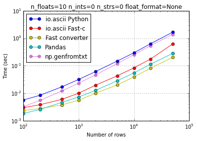

```python
plot_case(n_floats=10, n_ints=0, n_strs=0, float_format=None)
```